## ggplot / R markdown 연습문제

1.mpg 데이터의 cty(도시 연비)와 hwy(고속도로 연비) 간에 어떤 관계가 있는지 알아보려고 합니다. x축은 cty, y축은 hwy로 된 산점도를 만들어 보세요.

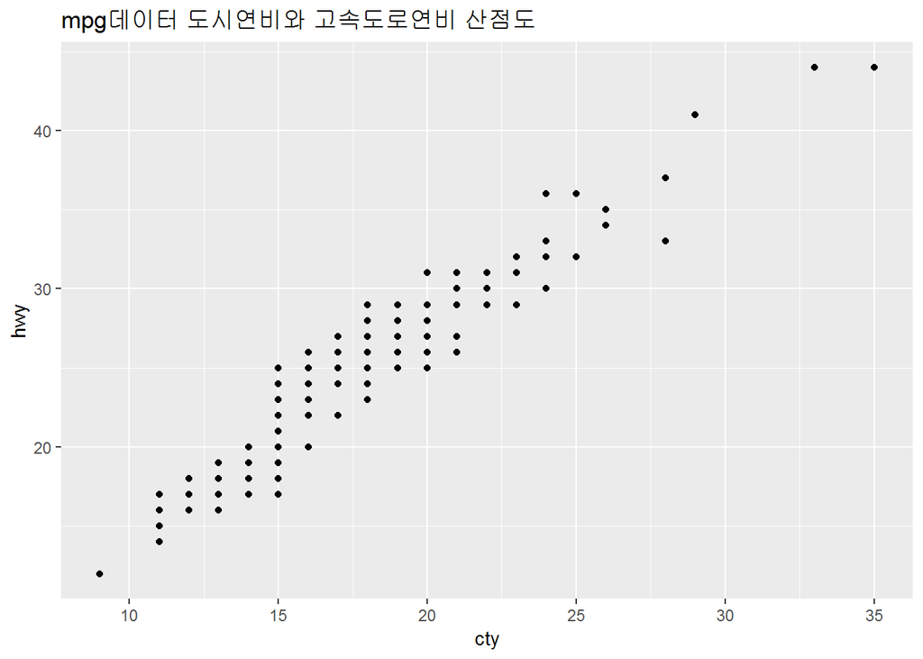

```r
ggplot(mpg,aes(x=cty,y=hwy)) +
  geom_point(stat="identity") +
  ggtitle('mpg데이터 도시연비와 고속도로연비 산점도')
```

2.미국 지역별 인구통계 정보를 담은 ggplot2 패키지의 midwest 데이터를 이용해서 전체 인구와 아시아인 인구 간에 어떤 관계가 있는지 알아보려고 합니다. x축은 poptotal(전체 인구), y축은 popasian(아시아인 인구)으로 된 산점도를 만들어 보세요. 전체 인구는 50만 명 이하, 아시아인 인구는 1만 명 이하인 지역만 산점도에 표시되게 설정하세요.

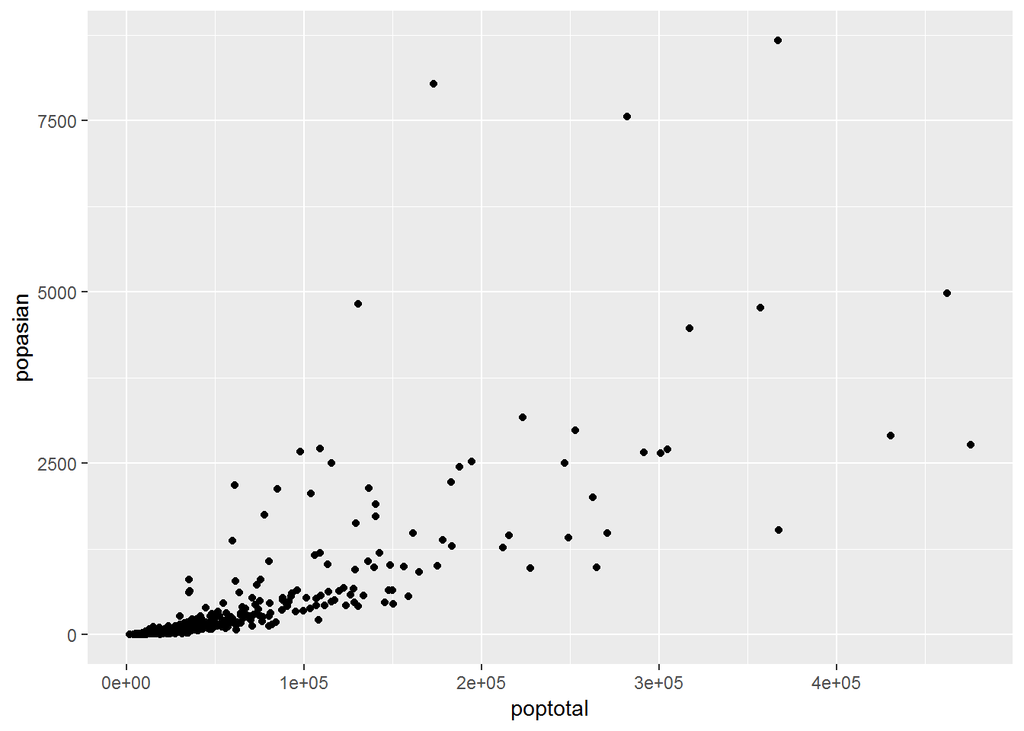

```r
p2<- midwest
poptotal <- p2 %>%
  filter(poptotal <= 500000, popasian <=10000)
ggplot(poptotal,aes(x=poptotal,y=popasian)) +
  geom_point(stat="identity")
```

3. 어떤 회사에서 생산한 “suv” 차종의 도시 연비가 높은지 알아보려고 합니다. “suv” 차종을 대상으로 평균 cty(도시 연비)가 가장 높은 회사 다섯 곳을 막대 그래프로 표현해 보세요. 막대는 연비가 높은 순으로 정렬하세요.

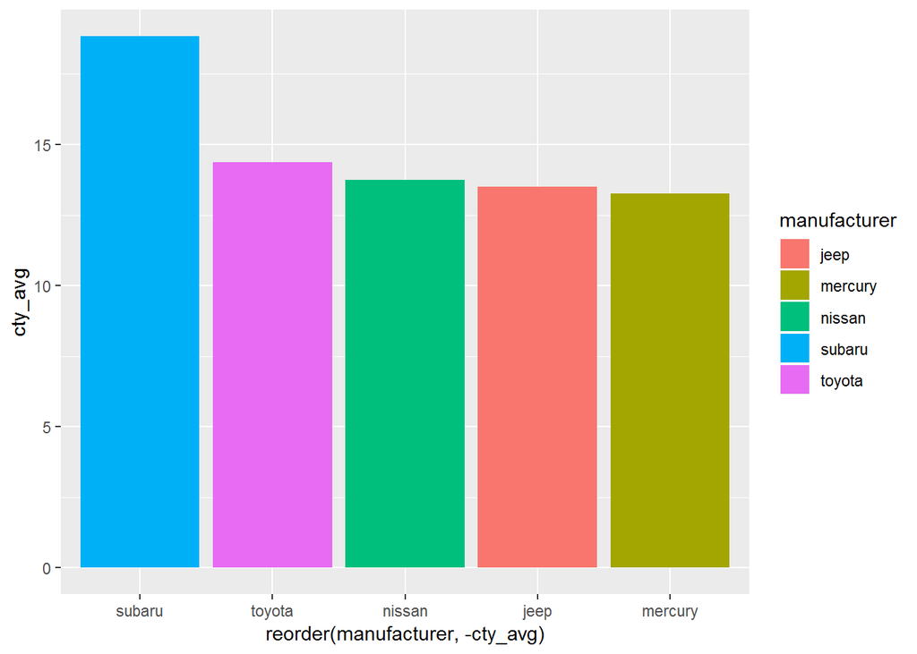

```r
p3 <- mpg
p4 <- p3 %>%
  group_by(manufacturer) %>%
  filter(class == "suv") %>%
  summarise(cty_avg = mean(cty))%>%
  arrange(desc(cty_avg))%>%
  head(5)
ggplot(p4, aes(x=reorder(manufacturer,-cty_avg),y=cty_avg,fill=manufacturer)) +
  geom_col()
```

4. 자동차 중에서 어떤 class(자동차 종류)가 가장 많은지 알아보려고 합니다. 자동차 종류별 빈도를 표현한 막대 그래프를 만들어 보세요.

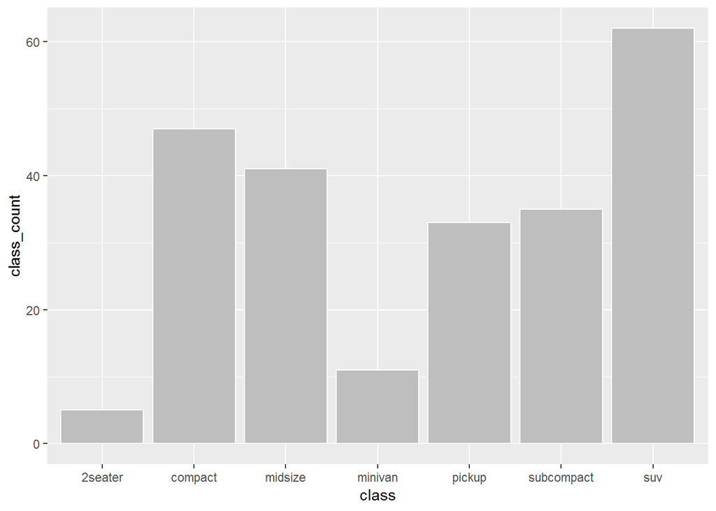

```r
p3 <- mpg
p5 <- p3 %>%
  group_by(class)%>%
  summarise(class_count = n()) %>%
  arrange(desc(class_count))
ggplot(p5, aes(x=class,y=class_count)) + geom_bar(stat="identity", fill= "grey", colour="white")
```

5.economics 데이터를 이용해서 psavert(개인 저축률)가 시간에 따라서 어떻게 변해왔는지 알아보려고 합니다. 시간에 따른 개인 저축률의 변화를 나타낸 시계열 그래프를 만들어 보세요.

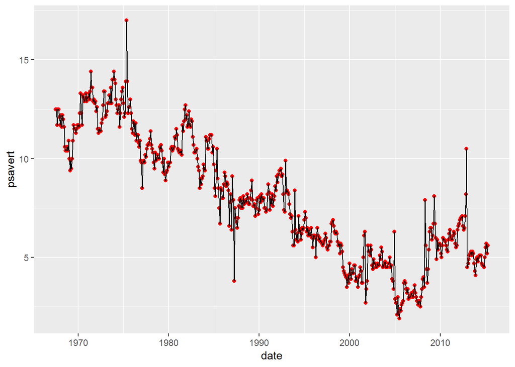

```r
p6 <-ggplot(economics,aes(x=date, y=psavert))
p6 + geom_point(color='red') + geom_line()
```

6.class(자동차 종류)가 “compact”, “subcompact”, “suv”인 자동차의 cty(도시 연비)가 어떻게 다른지 비교해보려고 합니다. 세 차종의 cty를 나타낸 상자 그림을 만들어보세요.

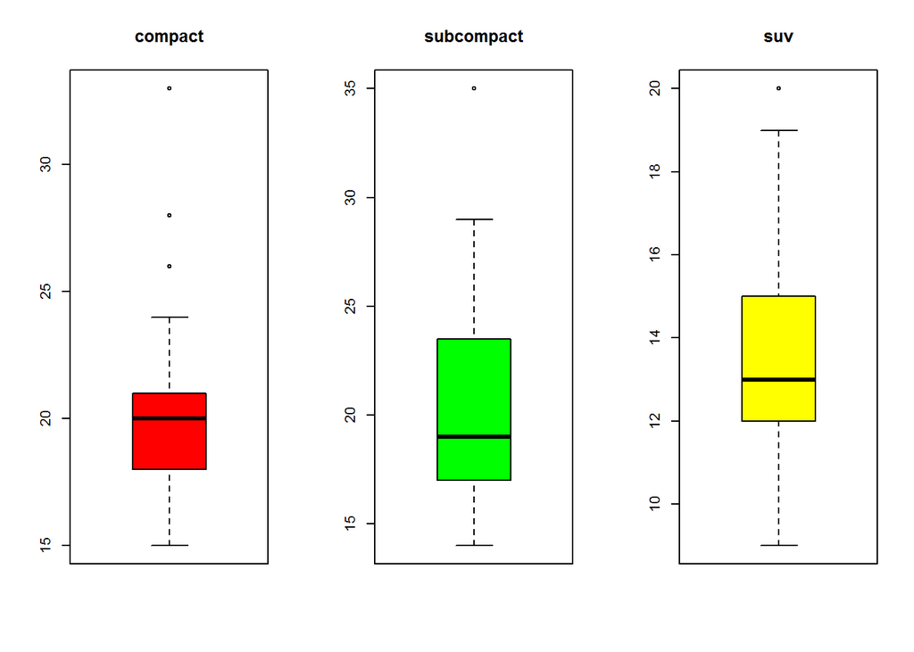

```r
p3 <- mpg


compact_cty <- filter(p3, class == 'compact')
subcompact_cty <- filter(p3, class == 'subcompact')
suv_cty <- filter(p3, class == 'suv')


par(mfrow=c(1,3))
boxplot(compact_cty$cty,
        col=c('red'),
        names=c('compact_cty'),
        main='compact')

boxplot(subcompact_cty$cty,
        col=c('green'),
        names=c('subcompact_cty'),
        main='subcompact')

boxplot(suv_cty$cty,
        col=c('yellow'),
        names=c('suv_cty'),
        main='suv')
```

7. Diamonds 데이터 셋을 이용하여 다음 문제를 해결하세요. 단, 컬러, 제목, x축, y축 등 그래프를 예쁘게 작성하세요.

7-1. cut의 돗수를 보여주는 그래프를 작성하세요.

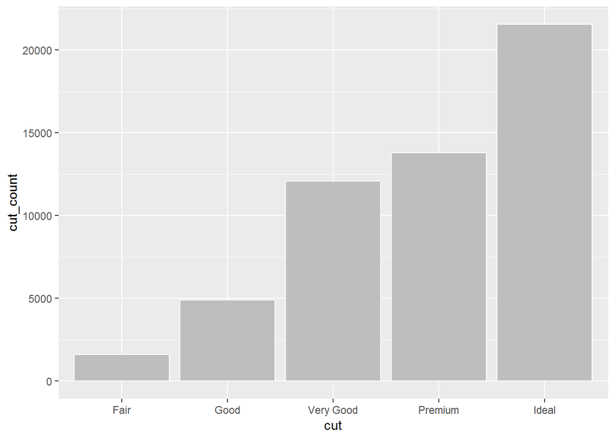

```r
p9 <- diamonds %>%
  group_by(cut)%>%
  summarise(cut_count = n()) %>%
  arrange(desc(cut_count))
ggplot(p9, aes(x=cut,y=cut_count)) + geom_bar(stat="identity", fill="gray", colour="white")
```

7-2. cut에 따른 가격의 변화를 보여주는 그래프를 작성하세요.

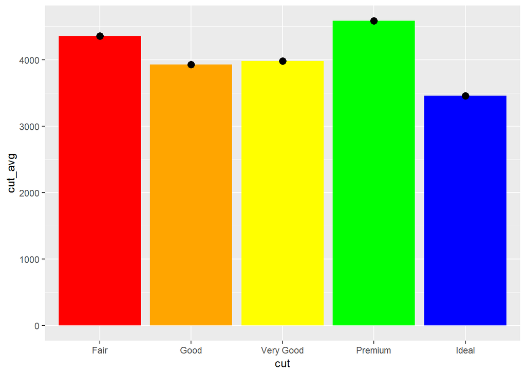

```r
p12 <-diamonds %>%
  group_by(cut) %>%
  summarise(cut_avg = mean(price))
ggplot(p12,aes(x=cut, y=cut_avg)) +
  geom_bar(stat="identity",fill=c('red','orange','yellow','green','blue')) +
  geom_point(color='black', size = 3)
```

7-3. cut과 color에 따른 가격의 변화를 보여주는 그래프를 작성하세요.

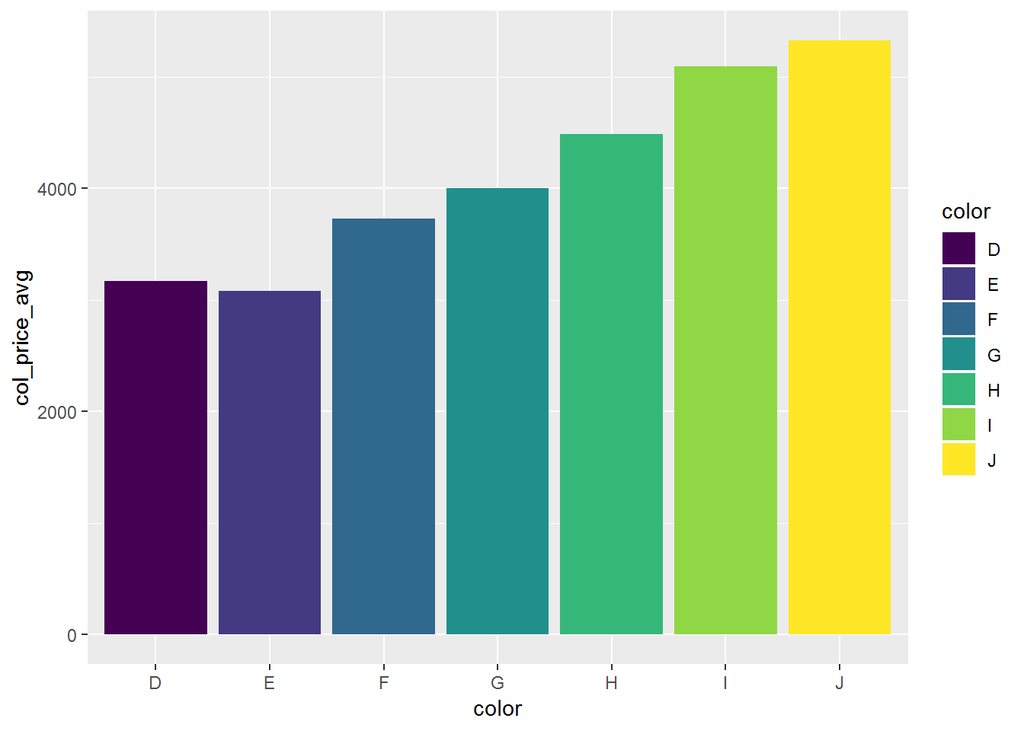

```r
p13 <- diamonds %>%
  group_by(color)%>%
  summarise(col_price_avg = mean(price))
ggplot(p13,aes(x=color,y=col_price_avg,fill=color)) + geom_col()
```